# Table of Contents

```python
import pandas as pd
import numpy as np

from sklearn.linear_model import LinearRegression
import statsmodels.api as sm
from statsmodels.sandbox.regression.predstd import wls_prediction_std
from sklearn.metrics import mean_squared_error,r2_score,explained_variance_score

from math import sqrt
from scipy import stats

import seaborn as sns
import matplotlib.pyplot as plt
%matplotlib inline

import warnings
warnings.filterwarnings("ignore")

import env
import util
from wrangle_zillow import wrangle_zillow
import explore
import split_scale
import features_zillow
import model_zillow
import evaluate

# Here's that cool piece of code from Zach to large numbers w/o sci notation
pd.options.display.float_format = '{:.3f}'.format
```

## Linear Regression

### **What is Linear Regression?**

**Regression is a Supervised Machine Learning technique** because we will be using **labeled data** where each example is a pair consisting of input value(s) and a desired output value. **Human involvement** is needed to feed the algorithm with training data containing the input(s)/predictor(s) and show it the correct output/target, so that the algorithm can 'learn' patterns from **historical data**, which it can use to predict outcomes for new, unseen data sets.

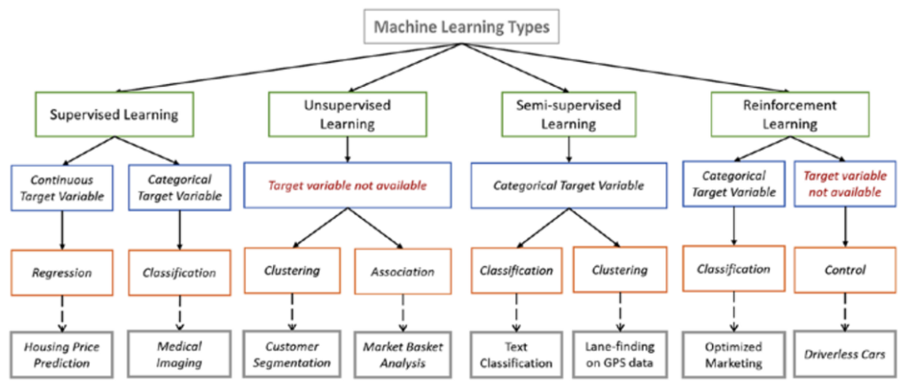

**A Simple Univariate Linear Regression** is used to model the relationship between **one independent or explanatory variable** and one continuous target or dependent variable using a straight line. The goal is to find the Line of Best Fit by finding the parameters, slope and y-intercept, that define the line and minimize regression errors.

> I want to use one feature, SAT score, to predict my continuous target variable, Freshman GPA.

**A Multiple Univariate Regression** is used to model the relationship between **more than one independent or explanatory variables** and one continuous target or dependent variable using a plane of best fit that minimizes regression errors. These can be linear and nonlinear. **Multiple Regressions assume no major correlation between the independent varaibles.**

> I want to use multiple features, square feet, bedroom count, bathroom count, to predict my continuous target variable, home value.

**Important Terms**

**X** - independent variable(s), predictor(s), feature(s)

**Capital 'X' signifies multiple features**

`X = df['feature']`

OR

`X = df[['feature1', 'feature2']]`

**y** - dependent variable, regressor, target

`y = ['target']`

### **So What?**

Here are a few of the main reasons people use regression analysis:

> - to predict future economic conditions, trends, or values
> - to determine the relationship between two or more variables
> - to understand how a change in an independent variable affects change in a dependent variable

### **Now What?**

We will work through the data science pipeline.

## Acquiring and Preparing - Wrangle

### **What is Wrangling?**

Data Wrangling is another way to say acquiring and preparinging data, so that it can be explored for insights or work well with machine learning algorithms. It can involve reading in data from a csv file, a SQL database, or wherever your data may be housed, it may require joins, and it will probably require some cleaning.

### **So What?**

Since you seriously will spend most of your time in the wrangle stage of the data science pipeline, let's get comfortable in here!

**Data Acquisition -** Read in the data you want to use in your project.

**Tip:** If you read in your data using a csv file and find that you have an extra column called 'Unnamed: 0', adding index_col=0 will get rid of that.

`df = pd.read_csv('your_data.csv', index_col=0)`

`df = pd.read_sql(query, url)`

**Data Characteristics and Summarization -** Once you read in your data, you will want to do some summarization to understand what shape your data is in and how much cleaning it may require.

`df.head()`

`df.shape`

`df.columns`

`df.info()`

`df.describe()`

`df.isna().sum()`

`df.column.value_counts(dropna=False)`

*This checks for any values less than 0 in a column/Series. Should return nothing if there are no values of 0 or less. If there are values of 0 or less, you will get an 'AssertionError.' Use this to test conditions in your data that should NEVER happen.*

`assert(df['col1'] >= 0 ).all()`

- The .all() method will check if all the elements in the objects pass the assert, while .any() will check if any of the elements in the objects pass the assert test. *(You could use a.empty, a.bool(), a.item(), a.any() or a.all())*

### **Now What?**

**You should end this section with a wrangle.py file that puts all of the code you used to acquire and clean your data into helper functions that feed a final wrangle function. This step should make your process repeatable, not only for yourself when you have new data, but for others trying to replicate your process.**

**Errors and Outliers -** Once you decide how you want to deal with any problem or NaN values, here's A WHOLE bunch of useful code snippets in one place to get you started!

> **Filter out extreme values.**

`df.column = df[df.column <= number]`

`df.column = df[mask for condition]`

**You may find that you need to deal with missing values. No problem!**

> **Fill NaN with 'something'**

`df['col'] = df['col'].fillna('something')`

> **Fill NaN with 99**

`df['col'] = df['col'].fillna(99)`

> **Fill NaN with the mean of the column**

`df['col'] = df['col'].fillna(df['col'].mean())`

> **Drop columns/rows that have any NaNs**

`df.dropna(axis=1)`/`df.dropna(axis=0)`

> **Only keep columns which have at least 90% non-NaNs (axis=0 for rows)**

`df.dropna(thresh=int(df.shape[0] * .9), axis=1)`

`df.Series.replace(original_value, desired_value, inplace=True/False)`

> **Create a new column based on a condition of another column**

`df['new_column'] = np.where(this_is_true, do_this, else_do_that)`

`df['new_column'] = np.where(df['col'].str.startswith('auto'), 'automatic', 'manual')`

> **Three level nesting with `np.where`**

```
df['new_column] = np.where(if_this_condition_is_true_one, do_this,
  np.where(if_this_condition_is_true_two, do_that,
    np.where(if_this_condition_is_true_three, do_foo, do_bar)))
```

> **Substitute each value in a Series with another value derived from a function, dictionary, or a Series using `.map()`**

`df['new_column'] = Series.map({'original string': 'new_string', 'original_string2': 'new_string2'})`

`df['new_column'] = Series.map({original_value: new_value, original_value2: new_value2})`

`df['percent'] = df.proportion.map(lambda x: x*100)`

## Splitting

### **What is Splitting?**

At this stage, you will create train (in-sample) and test (out-of-sample) dataframes using the train_test_split function from Sklearn. This will randomly split your dataset into train and test by the percentage you pass into the function. You will use the train set to do exactly that, train your model to make predictions. You will use your test set to evalute your model's performance on unseen data and ensure that it didn't learn too much from your train set causing it to 'overfit' on a particular set of data.

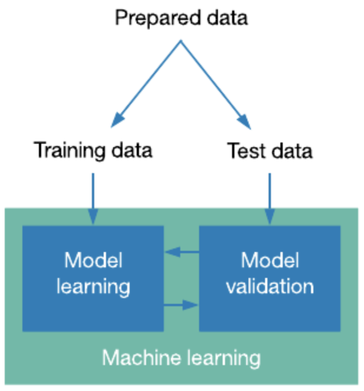

**Be Aware:** You may need to stratify your split on a particular feature, so that the proportion of a features' values is the same in both your train and test sets. You can pass the stratify parameter as an option to your train_test_split. `sklearn.model_selection.train_test_split(df, train_size=.75, random_state=123, stratify=target_variable)`

For more on train_test_split, this is a GREAT introductory article!

https://towardsdatascience.com/6-amateur-mistakes-ive-made-working-with-train-test-splits-916fabb421bb

### **So What?**

You may **explore individual variables before splitting** your data into train and test sets, so that you can identify outliers, Nulls, etc. However, **when looking at interactions of variables**, your data should first be split before you explore. You should also split your data into train and test before you scale. This is because your test data should remain unseen as much as possible as it is supposed to be unknown at this stage.

An important component of Data Science is that peers must be able to replicate what you have done to your data, especially if you are going to deploy your model to be used in the future. By splitting your data into train and test sets early on in the pipeline, you are validating that any processing you completed on your train set is repeatable on your test set as well as unseen future sets.

### **Now What?**

`from sklearn.model_selection import train_test_split`

`train, test = train_test_split(df, train_size=.75, random_state=123)`

> **Decide on your independent (X) variable(s) and dependent (y) variable.**

`X_train = train[['independent_var1', 'independent_var2', 'independent_var3']]`

`y_train = train['dependent_var']`

`X_test = test[['independent_var1', 'independent_var2', 'independent_var3']]`

`y_test = test['dependent_var']]`

> **Do a quick check. Although the row count will differ, the column count should not. Always make sure the data you're working with is the data you THINK you're working with.**

`train.shape` and `test.shape`

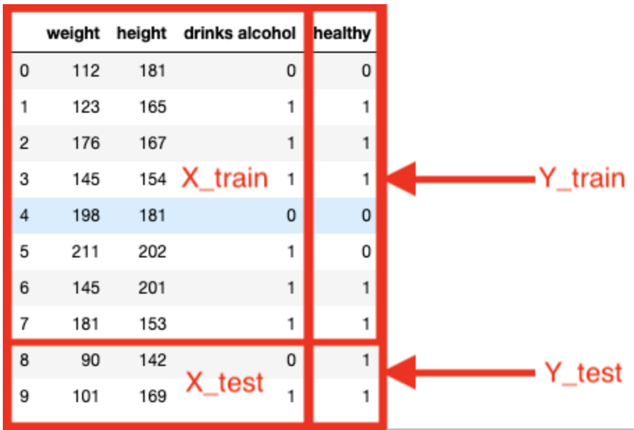

OR

`X = [['independent_var1', 'independent_var2', 'independent_var3']]`

`y = ['dependent_var']`

`X_train, X_test, y_train, y_test = train_test_split(X, y, train_size=.75, random_state=123)`

## Scaling

### **What is Scaling?**

To scale your data is basically to change the range of values of your features while preserving their distributions. Scaling your features in a Multiple Linear Regression when they have different units of measurement ensures that your ML algorithm does not emphasize your variables with larger measurement scales. In other words, since most ML algorithms pay no attention to units of measurement, scaling allows all of your features to contribute equally to your algorithm.

**Standardization (Z-score Normalization) -** This is when you scale your features so that they have the properties of a standard normal distribution where $\mu$ = 0 and $\sigma$ = 1. It replaces your values with their Z-scores.

**Normalization -** This scales the data to a fixed range, usually 0 to 1. One of the costs of this range is that you will end up with smaller standard deviations which **can supress outliers**. You should take this into consideration when deciding on a Min-Max Scaler or data Normalization.

Here is a gret introductory article on different scalers.

https://towardsdatascience.com/scale-standardize-or-normalize-with-scikit-learn-6ccc7d176a02

### **So What?**

**Why is scaling useful?**

First and foremost, if you don't need to scale your data, don't! It adds complexity to your data, so never scale for scaling sake. That being said, scaling can help you better explore patterns in some data or it may be a necessary step before running statistical tests or applying machine learning algorithms.

Most Machine Learning algorithms use Euclidean distance between two data points in their computations. **If you are using more than one feature to predict your target**, and your features use different units of measurement, then scaling the data ensures that variables are weighted equally. *There are some algorithms that do not benefit from scaling such as tree-based methods and Naive Bayes.*

> For Example, 3500 square feet and 5 bedrooms. The feature of square feet will weigh a lot more than the bedrooms feature.

You may need to scale data that is not a normal distribution to be a normal distribution **for statistical testing**. However, it is not always possible to just scale the feature to a normal distribution. You may need to first drop the outliers and then scale it, which will help it turn into a normal distribution.

### **Now What?**

If you are not going to be modeling and are purely looking at analyzing historical data, you could scale your entire dataset. Otherwise, your test needs to remain unseen, and therefore you fit your scaler to your train and then transform your train and test sets with that scaler that has been fit to your train dataset.

> **Which scaler should I use?**
- All things being equal, use the simplest one. StandardScaler and MinMaxScaler are the most commonly used and are a great place to start.
- Do you need your outliers to look like outliers? Do you need to maintain the space between your values or do you want to Normalize the space between values.
- The link below has great comparisons of scalers with visuals explanations!

https://scikit-learn.org/stable/auto_examples/preprocessing/plot_all_scaling.html

> **Linear transformations**
- **MinMaxSclaer (min-max Normalization) -** This changes the units on the x-axis by scaling your values to range between 0 and 1, but it does not change the distribution or shape of your data. This preserves the distance between each value. **This scaler is very sensitive to the presence of outliers.**
- **Standarized Scaler (z-score Standardization) -** This scaler removes the mean and scales the data to unit variance making it more understandable. However, the outliers have an influence when computing the empirical mean and standard deviation which shrink the range of the feature values. **This scaler is very sensitive to the presence of outliers.**
- **Robust Scaler -** Preserves your outliers making it 'robust' to outliers in your dataset. The centering and scaling statistics of this scaler are based on percentiles and are therefore **not influenced by a few number of very large marginal outliers.**

> **Non-linear transformations**

*Non-linear transformations can change the outcome of your statistical tests, and actually the underlying assumption of a T-Test, for example, is that your data has a normal distribution, so if you start with data that is NOT normally distributed, a non-linear transformer can help you prepare your data for statistical tests.*

- **Quantile and Power Transformations -** **QuantileTransformer** provides non-linear transformations in which distances between marginal outliers and inliers are shrunk. **PowerTransformer** provides non-linear transformations in which data is mapped to a normal distribution to stabilize variance and minimize skewness. It applies a power transformation to each feature to make the data more Gaussian-like. *These transformations tend to spread out the most frequent values.*
- **Uniform or Normal Distributioins -** These are both `output_distribution` types for the QuantileTransformer. The default output_distribution is uniform and applies the non-linear transformation such that the probability density function of each feature will be mapped to a uniform distribution. When set to normal, it rescales the vector for each sample to have unit norm, independently of the distribution of the samples.
- **Box-Cox v Yeo-Johnson -** These are both methods of PowerTransformer that return zero means and normalize unit variance. Yeo-johnson allows for negative data while box-cox allows positive data only.

> **Log transformations -** This technique helps to handle skewed data, and after transformation, the distribution becomes more approximate to normal. It takes a dataset with differences in orders of magnitude (1, 10, 100, 1000, 10_000) and changes the scale of the y-axis to a log scale which allows us to see differences better. It handles datasets with exponential curves better, think Telco Tenure, Zillow Home Values, or our current pandemic!)

`out_array = np.log(in_array)`

> Import desired scalers from sklearn.preprocessing

`from sklearn.preprocessing import StandardScaler, MinMaxScaler`

**Remember:** SKlearn expects a 2D array or DataFrame. `df[['age']]` == 2D array or DataFrame `df['age]` == 1D array or Series

> **Create** -> Create the Scaler Object

`scaler = StandardScaler` OR `scaler = MinMaxScaler()`

> **Fit** -> Fit the Scaler Object to **X_train only**

`scaler.fit(X_train)`

> **Transform** -> Transform X_train and X_test using the Scaler Object we fit to our train data

`X_train_scaled = scaler.transform(X_train)`

`X_test_scaled = scaler.transform(X_test)`

**Remember:** SKlearn returns a 2D numpy array from its transformation, so the following code will return your transformed (scaled) data as a Pandas DataFrame `X_train_scaled = pd.DataFrame(scaler.transform(X_train), columns=X_train.columns, index=X_train_index)` `X_test_scaled = pd.DataFrame(scaler.transform(X_test), columns=X_test.columns, index=X_test_index)`

## Exploring

### **What is Exploring?**

> “Design cannot rescue failed content.” ― Edward R. Tufte

Exploratory Data Analysis (EDA) is how you get to know your data or the content of all of your future processes in the data science pipeline. The importance of this stage cannot be stressed enough. How can you be sure of what you have if you have not taken the time to thoroughly explore the relationships in your data? The truth is that you can't.

### **So What?**

This is an important step that shouldn't be rushed, so allow for a good amount of time to explore your data. Data Visualization is an awesome part of this stage, but it's not the only part. We can look at code here both to explore and to visualize for a better understanding of our data.

### **Now What?**

**Data Characteristics and Summarization**

*Some of your exploration has been accomplished in the acquire and prep stages, but as you know, running through the data science pipeline is not a linear process. **Exploration would be better characterized as a thread that runs throughout all of the stages.** I would suggest checking the characteristics of your data often, like at the start of each stage or before and after each major manipulation you perform on your data.*

For code snippets, see Characterization and Summarization

**Find and Handle Errors and Outliers**

For code snippets, see Errors and Outliers

**Distribution of Features and Target**

> **Quick look at distribution of all numeric columns in df**

`df.hist(grid=False, figsize=(16,12), color='purple')`

> **Create a distplot to explore the distribution of a Pandas Series**

`sns.distplot(Series, bins=None, hist=True, kde=True, rug=False, fit=None, hist_kws=None, kde_kws=None, rug_kws=None, fit_kws=None, color=None, vertical=False, norm_hist=False, axlabel=None, label=None, ax=None)`

> **Create a boxplot to get an idea of the distribution as well as possible outliers**

`sns.boxplot(x=None, y=None, hue=None, data=None, order=None, hue_order=None, orient=None, color=None, palette=None, saturation=0.75, width=0.8, dodge=True, fliersize=5, linewidth=None, whis=1.5, ax=None, **kwargs)`

**Relationships Between the Features**

> **Explore correlation using a Heatmap**

`sns.heatmap(df.corr(), cmap='Purples', annot=True)`

> **Explore correlation using this nifty function I built**

```
def correlation_exploration(df, x_string, y_string):
    r, p = stats.pearsonr(df[x_string], df[y_string])
    df.plot.scatter(x_string, y_string)
    plt.title(f"{x_string}'s Relationship with {y_string}")
    print(f'The p-value is: {p}. There is {round(p,3)}% chance that we see these results by chance.')
    print(f'r = {round(r, 2)}')
    plt.show()
```

## Evaluating

### **What does it mean to Evaluate your model?**

There is a noteworthy saying that *“All models are wrong but some of them are useful.”* Keeping that in mind, how do we know if our model is useful?!

> **Evaluating a model** is when we use specific metrics to measure how well our model can predict our target variable, y, using our chosen feature(s), X.

> **Important Terminology:**
- **y:** The actual target value (y variable value)
- **$\hat{y}$ or yhat:** The predicted target value (predicted y variable value)
- **$\bar{y}$ or ybar:** The mean of all of the actual target values (mean of all y variable values). This is your Baseline prediction value.

  A Baseline prediction is when you predict that every target value will be equal to the mean of all of the target values or ybar.

> What is the best I can predict without using a variable? **If your model can't beat your Baseline prediction, scrap that model!** *'If the mean or median of your target variable is a good predictor of your target variable, you don't need to model at all.' - Ryan Orsinger*
- **Residuals:** A residual is the difference between each predicted value, yhat, and each actual value, y. So, when you talk about the residuals of your model, you are talking about the amount of error your model has. If your model had 0 residuals, it would mean that your model was predicting at 100%. (A model predicting at 100% should be a red flag, BTW.)

> **Metrics for evaluating models:**
- **Sum of Squared Errors (SSE):** All of the residuals squared and added together. ($\hat{y}$ - y)$^2$ == (y - $\hat{y}$)$^2$. **This metric is not good for comparing model performance on datasets with different numbers of observations, such as train and test.**
- **Mean Squared Error (MSE):** The SSE divided by the number of observations. **This metric can be used to compare the performance of a model on datasets with different number of observations** because it is the mean.
- **Root Mean Squared Error (RMSE):** The square root of the MSE makes the measurement more meaningful because **it puts the value back in the original units of the target variable.** Along with MSE, **this metric can be used to compare the performance of a model on datasets with different numbers of observations**, such as train and test.

  **Evaluating whether RMSE is sufficiently small or not will depend on how accurate we need our model to be for our given application. There is no one answer for all data in general.**
- **$R^2$ or Explained Variance (score ranges from 0 to 1):** This tells you how much of the change in your y variable can be explained by your X variables. (Coefficient of Determination == Pearson's R squared) Only used in linear models. **For Example:** If $R^2$ = 0.43 for your regression equation, then it means that 43% of the variability in y is explained by the variable(s) in X.

> A high $R^2$ score means that X is a valuable predictor for your y value. *(The significance of this score depends on your p-value.)*

> A low $R^2$ means that your X is not a valuable predictor for you y value. *(The significance of this score depends on your p-value.)*
- **F-regression test (p-value):** It compares a model with no predictors to the model that you specify. The metric it returns, p-value, tells you whether your $R^2$ score is significant.

  **What is the probability the RMSE of our trained model on this set of observations would be this small by random chance?**

### **So What?**

> **Does the model add value?**
- Does it perform better than if I made a random guess at my target value?
- Does it perform better than if I predicted the average value of the y value every time?
- Does it perform better than any existing model I have?
- How much confidence should I have in this model?

### **Now What?**

> **Define X and y variables**

`X = df[[independent variable(s)]]`

`y = df[[dependent variable]]`

> **Create a Baseline**

**- Use the mean or median of the target variable as every baseline_yhat value.**

`baseline_yhat = y.mean()`

OR

`baseline_yhat = y.median()`

> **Create a Model (for example - an ols model predicting home_value using bedrooms, bathrooms, and square_feet as features)**

**- Import ols**

`from statsmodels.formula.api import ols`

**- Create Model**

`ols_model = ols(formula='home_value ~ bedrooms + bathrooms + square_feet', data=train).fit()`

**- Predict on Model**

`ols_yhat = ols_model.predict(X_train)`

> **Evaluate Your Model against your Baseline Using RMSE**

**- Create a Handy DataFrame for Evaluating Your Models or Model and Baseline Value**

`ols_eval = y_train.copy()`

`ols_eval.rename(columns={'home_value': 'actual'}, inplace=True)`

**- Add Baseline Value Column**

`ols_eval['baseline_yhat'] = ols_eval['actual'].mean()`

**- Add ols Predictions Column**

`ols_eval['ols_yhat'] = ols_model.predict(X_train)`

**- Calculate and Add Residuals Column for Plotting**

`ols_eval['residuals'] = ols_eval.ols_yhat - ols_eval.actual`

**- Compute the RMSE for our ols Model and Baseline Using Your Handy DataFrame**

`from sklearn.metrics import mean_squared_error` `from math import sqrt`

`baseline_RMSE = sqrt(mean_squared_error(ols_eval.actual, ols_eval.baseline_yhat))`

`ols_RMSE = sqrt(mean_squared_error(ols_eval.actual, ols_eval.ols_yhat))`

`print(f'My model has value: {ols_RMSE < baseline_RMSE}')`

`ols_r2 = round(ols_model.rsquared,3)`

`ols_p_value = ols_model.f_pvalue`

`print(f'My R-squared score is significant: {ols_p_value < .05}')`

**If the RMSE for your ols model is smaller than the RMSE for your Baseline, and your p-value is less than your alpha, your model has value.**

OR

**- Look at the R-squared and Prob (F-statistic) values in the summary chart**

`ols_model.summary()`

> **Visualize Residuals**

**- Quick look at distribution of residuals**

`plt.hist(np.log(ols_eval.residuals))`

**- Look for Patterns in Actual vs Residuals**

`plt.scatter(ols_eval.actual, ols_eval.residuals)`

**- Look at Predictions vs Residuals**

`plt.scatter(ols_eval.ols_yhat, ols_eval.residuals)`

> **If Your First Model Beats Your Baseline, Try to Beat your First Model**

**- Use the RMSE metric to compare the performance of successive models you build.**

# Part II with Feature Engineering and Modeling Coming Soon...